# In-Class Assignment 10

**Instructions:**

- For questions that require coding, you need to write the relevant code and display its output. Your output should either be the direct answer to the question or clearly display the answer in it.
- For questions that require a written answer (sometimes along with the code), you need to put your answer in a Markdown cell. Writing the answer as a comment or as a print line is not acceptable.
- Receiving help from classmates and/or ideas from Generative AI is allowed. **However, you must submit your own original work.**
- You need to render this file as HTML using Quarto and submit the HTML file. **Please note that this is a requirement and not optional.** A submission cannot be graded until it is properly rendered.

Import all the libraries and tools you need below.

```python
# You need the line given below to install the UMAP library.
!pip install umap-learn
import numpy as np
import pandas as pd
import matplotlib.pyplot as plt

from sklearn.model_selection import train_test_split, GridSearchCV
from sklearn.preprocessing import StandardScaler
from sklearn.metrics import accuracy_score, recall_score, precision_score, classification_report
from sklearn.decomposition import PCA, KernelPCA
from sklearn.manifold import TSNE
from umap import UMAP
```

**Before you start, please note that the interpretations of some figures you will create can be open-ended, since there is not any numeric evaluation in this assignment. Answer the questions that concern the output figures according to what you see on the figures.**

### 1)

Read the data from **customer_churn.csv**. Each observation represents a customer in a telecommunications company. The `Churn` variable represents whether the customer cancelled (1) their subscription at the end of a 12-month period or not (0) and is the target/response variable. All the other variables are the predictors. Their names should be self-explanatory.

Separate the response and the predictors. You will not predict anything in this assignment, so the responses will be for color-coding the classes only.

**(2.5 points)**

```python
# Read data
customer_churn = pd.read_csv('customer_churn.csv')

# Separate predictors and responses
X = customer_churn.drop(['Churn'], axis= 1)
y = customer_churn['Churn']
```

### 2)

(Standard) scale the predictors. Note that you will use the entire dataset in this part and the remainder of this assignment. **(2.5 points)**

```python
# Scale the predictor (Not splitting)
scale = StandardScaler()
scale.fit(X)
X_scaled = scale.transform(X)
```

### 3)

Using Principal Component Analysis (PCA), reduce the data to two dimensions. Find and print the percentage of variance from the original data that is retained by the lower-dimensional data. **(10 points)**

```python
# Reduce data to two dimensions
pca = PCA(n_components= 2)
pca.fit(X_scaled)
X_pca = pca.transform(X_scaled)

# Get the explained variance ratio
variance_kept = pca.explained_variance_ratio_

# Print the percentage of variance retained with two dimensions
print(f'Retained Variance: {sum(variance_kept) * 100:.2f}%')
```

```
Retained Variance: 48.75%
```

### 4)

Create a scatter plot of the lower-dimensional data and color-code the points with the classes. Set the transparency of the points to 0.1, so you can see the overlapping classes well.

Do the classes look separable by any classifier that is trained on the lower-dimensional data? How does this relate to the retained variance you found in the previous question?

**(10 points)**

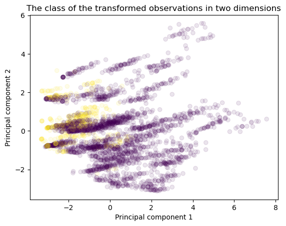

```python
# Change x back to dataframe
X_pca = pd.DataFrame(X_pca, columns= ['PC1', 'PC2'])

# Create a scatterplot
plt.scatter(X_pca['PC1'], X_pca['PC2'], c = y, alpha= 0.1)
plt.title('The class of the transformed observations in two dimensions')
plt.xlabel('Principal component 1')
plt.ylabel('Principal component 2')
plt.show()
```

The data shown in a picture is very overlapped between classes, and thus seems unable to separate.

### 5)

One way to possibly improve the retained information during dimensionality reduction is to use a [Kernelized PCA](https://scikit-learn.org/stable/modules/generated/sklearn.decomposition.KernelPCA.html) model. Explain why kernelization can be more beneficial while applying PCA to a dataset. **(5 points)**

Kernel PCA, capturing the non-linear pattern by mapping data into higher dimensionality before applying PCA, is particularly beneficial for dimensionality reduction since it will captures the non-linear relationship between predictors in the original data. As the real world data often has non-linear relationship rather than linear one, kernel PCA will make dimensionality reduction more efficient.

### 6)

Either using a loop or manually, repeat Questions 3 and 4 with: (1) an `rbf` kernel with a gamma value of 0.1, 1 and 10 and (2) a `poly` kernel with a degree of 2, 3, and 4. Does the lower-dimensional representation get more classifiable?

**Note:** You need to display 6 figures in total.

**(15 points)**

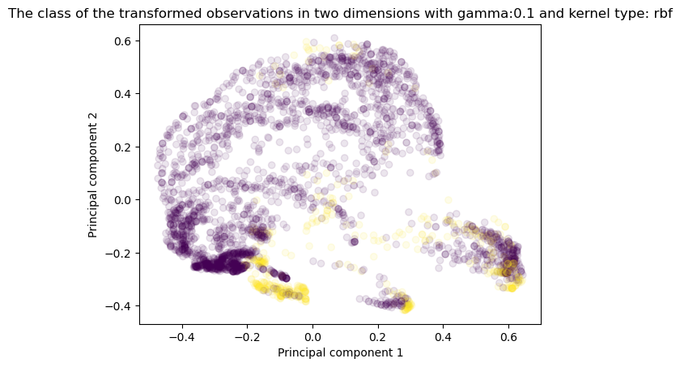

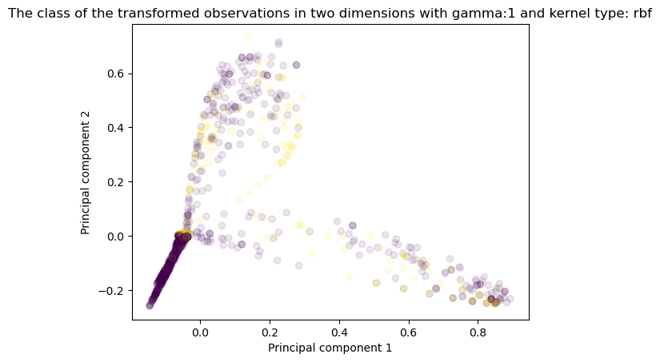

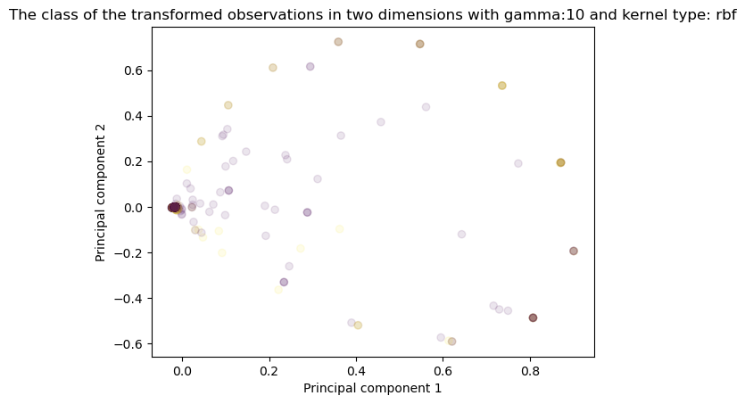

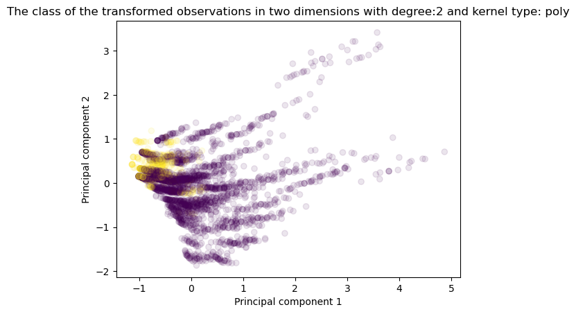

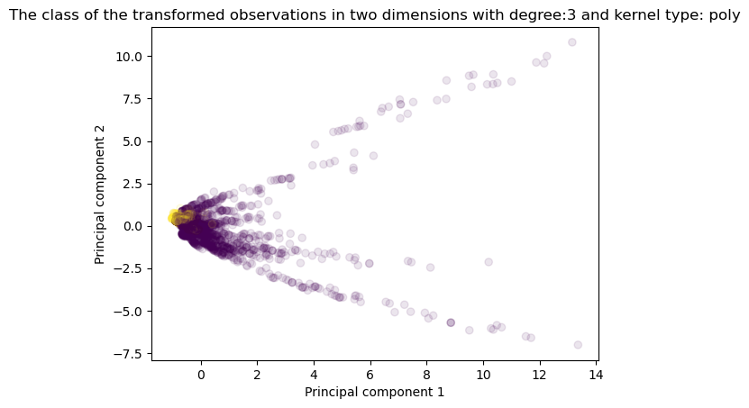

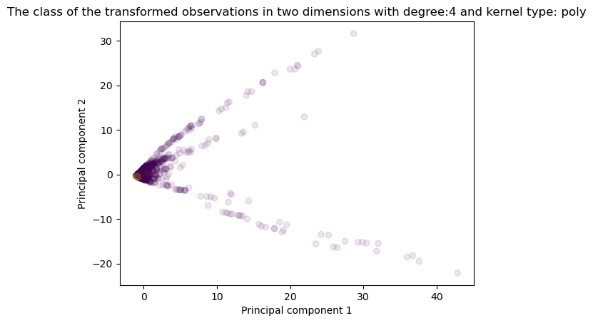

```python
# Repeat Q3, 4 with rbf and poly
gamma_value = [0.1, 1, 10]
poly_degree = [2, 3, 4]

# Loop through all possible values
for gamma in gamma_value:
        pca = KernelPCA(n_components= 2, kernel=  'rbf', gamma= gamma)
        pca.fit(X_scaled)
        X_pca = pca.transform(X_scaled)

        # Change x back to dataframe
        X_pca = pd.DataFrame(X_pca, columns= ['PC1', 'PC2'])

        # Create a scatterplot
        plt.scatter(X_pca['PC1'], X_pca['PC2'], c = y, alpha= 0.1)
        plt.title(f'The class of the transformed observations in two dimensions with gamma:{gamma} and kernel type: rbf')
        plt.xlabel('Principal component 1')
        plt.ylabel('Principal component 2')
        plt.show()

for degree in poly_degree:
        pca = KernelPCA(n_components= 2, kernel=  'poly', degree= degree)
        pca.fit(X_scaled)
        X_pca = pca.transform(X_scaled)

        # Change x back to dataframe
        X_pca = pd.DataFrame(X_pca, columns= ['PC1', 'PC2'])

        # Create a scatterplot
        plt.scatter(X_pca['PC1'], X_pca['PC2'], c = y, alpha= 0.1)
        plt.title(f'The class of the transformed observations in two dimensions with degree:{degree} and kernel type: poly')
        plt.xlabel('Principal component 1')
        plt.ylabel('Principal component 2')
        plt.show()
```

The lower dimension seems to be more classifiable for poly kerne (with degree 3) but not for rbf kernel.

### 7)

Reduce the data to two dimensions using a T-SNE model. Use `random_state=2` and **the 40 nearest neighbors** of an observation to find its place in two dimensions. Recreate the color-coded scatter plot of the lower-dimensional data. Use a transparency of 0.1 again. Do the classes look more separable with T-SNE (compared to PCA)?

**(15 points)**

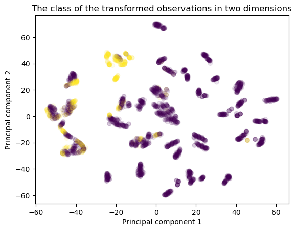

```python
# Apply T-SNE
t_sne = TSNE(n_components= 2, random_state= 2, perplexity= 40)
X_tsne = t_sne.fit_transform(X_scaled)

# Change x back to dataframe
X_tsne = pd.DataFrame(X_tsne, columns= ['PC1', 'PC2'])

# Create a scatterplot
plt.scatter(X_tsne['PC1'], X_tsne['PC2'], c = y, alpha= 0.1)
plt.title(f'The class of the transformed observations in two dimensions')
plt.xlabel('Principal component 1')
plt.ylabel('Principal component 2')
plt.show()
```

### 8)

In the previous questions, you should have observed that dimensionality reduction with T-SNE takes much longer to run than PCA. Why is this the case? How would the runtime change as the number of neighbors in T-SNE increase? **(10 points)**

Dimensionality reduction in T-SNE is a non-linear method with two important steps: local pairwise similarity computation and iterative optimization. These two steps make T-SNE more computationally costly than the linear PCA. In addition, with higher number of neighbors in consideration, the higher number of operations are needed for local similarity computation (compared to all neighbors). Therefore, the overall run time of T-SNE is more computationally expensive compared to PCA due to its underlying non-linear algorithm. Also, the more number of neighbors, the more time needed.

### 9)

Reduce the data to two dimensions using a [UMAP](https://umap-learn.readthedocs.io/en/latest/index.html) model. Use `random_state=2`. Read about the model behavior with `n_neighbors` and `min_dist` inputs in the (linked) model documentation. You will only use these two inputs in this question and leave the other inputs (except `random_state`) as default.

Set `n_neighbors` and `min_dist` to values that return the most classifiable two-dimensional representation of the data in this assignment (maybe except Kernelized PCA). Recreate the color-coded scatter plot of the lower-dimensional data. Use a transparency of 0.1 again.

**Note:** Tuning the two main inputs of UMAP entirely consists of trial and error. Just try out different values and observe how the two-dimensional representation looks.

**(20 points)**

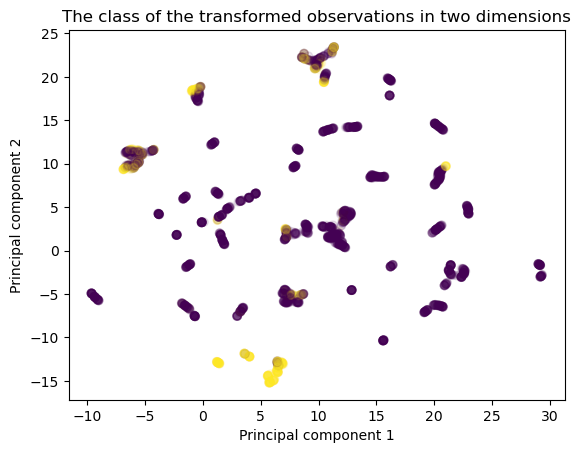

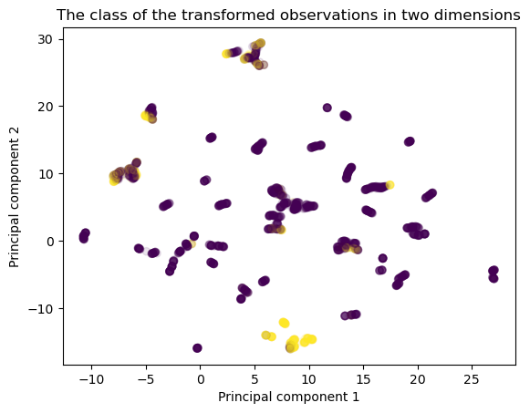

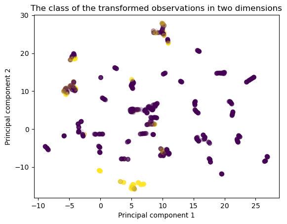

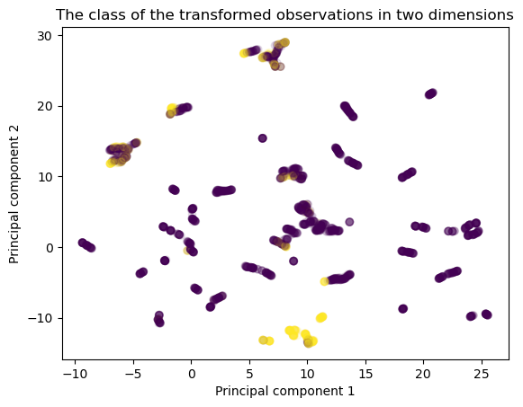

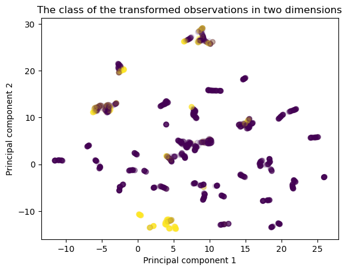

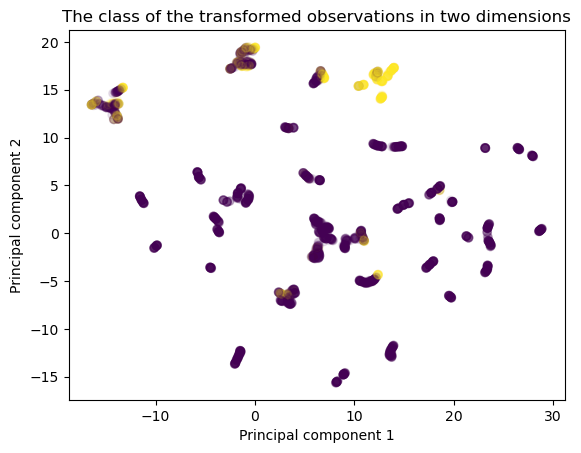

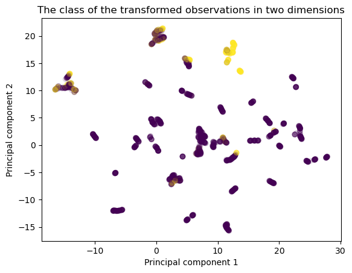

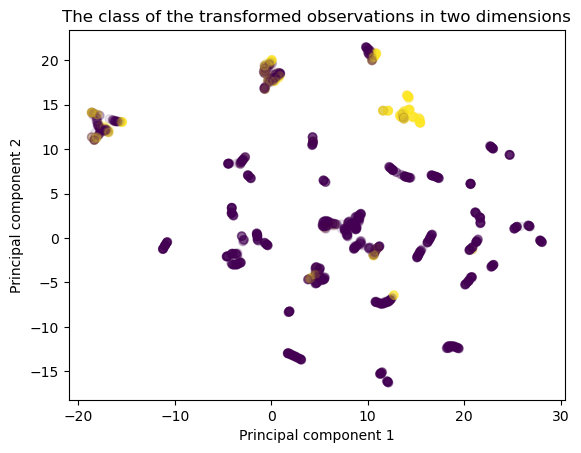

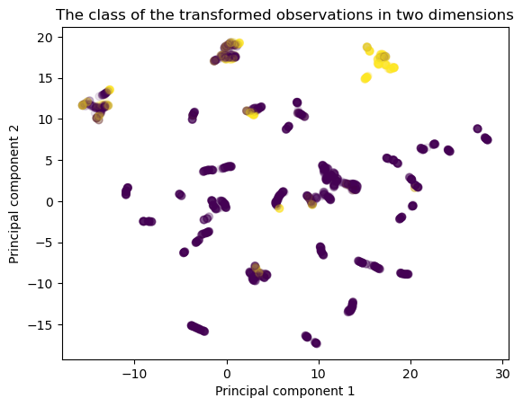

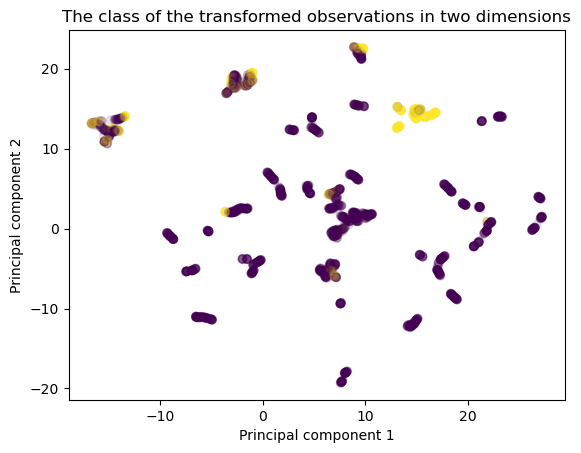

```python
# Reduce dimensionality of data with UMAP
neighbors = [25, 30]
dist = np.linspace(0.09,0.13, num= 5)

for neighbors in neighbors:
    for min_dist in dist:
        umap = UMAP(n_neighbors= neighbors, min_dist= min_dist, random_state= 2)
        X_umap = umap.fit_transform(X_scaled)
        # Change x back to dataframe
        X_umap = pd.DataFrame(X_umap, columns= ['PC1', 'PC2'])

        # Create a scatterplot
        plt.scatter(X_umap['PC1'], X_umap['PC2'], c = y, alpha= 0.1)
        plt.title(f'The class of the transformed observations in two dimensions')
        plt.xlabel('Principal component 1')
        plt.ylabel('Principal component 2')
        plt.show()
```

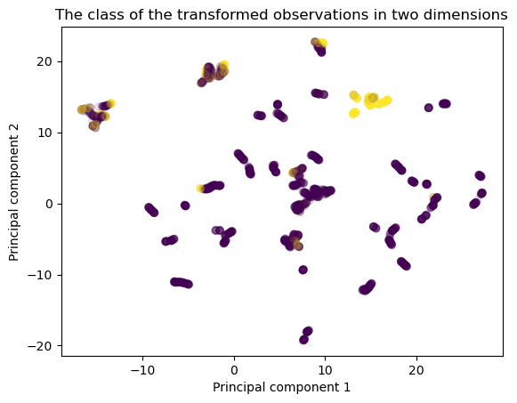

```python
# After all trial and errors above, we choose the best one
umap = UMAP(n_neighbors= 30, min_dist= 0.13, random_state= 2)
X_umap = umap.fit_transform(X_scaled)
# Change x back to dataframe
X_umap = pd.DataFrame(X_umap, columns= ['PC1', 'PC2'])

# Create a scatterplot
plt.scatter(X_umap['PC1'], X_umap['PC2'], c = y, alpha= 0.1)
plt.title(f'The class of the transformed observations in two dimensions')
plt.xlabel('Principal component 1')
plt.ylabel('Principal component 2')
plt.show()
```

It seems like neighbour = 30 and min_dist = 0.13 provides one of the cleanest clustering for class separation.

### 10)

For the T-SNE and UMAP models, do the new dimensions have any insight? Can they be formulated like the Principal Components of PCA? How about captured variance for each dimension? What does this say about the T-SNE and UMAP models? **(10 points)**

Both T-SNE and UMAP are both non-linear dimensionality reduction techniques, transforming data from higher dimensions to lower dimension and preserve both local and global patterns. As the T-SNE and UMAP applying neighbours and distances to find the principal components for dimensionality reduction, the captured variance by each principal component cannot be determined. In addition, since these two methods apply non-linear and non-parametric transformations, their derived PC cannot be interpreted as a linear combination of the original predictors. On the other hand , the PCA algorithm utilizes the order of variance kept by each principal components and the PCs can be easily interpreted through the linear combination of original predictors. Therefore, T-SNE and UMAP will be ery useful for data with non-linear pattern which is the fact for most of the real-world data. However, the interpretibility of the principal components derived from them is limited.